[figure not shown]

[figure not shown]

# Insights

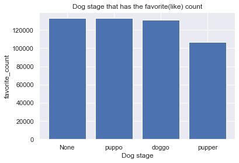

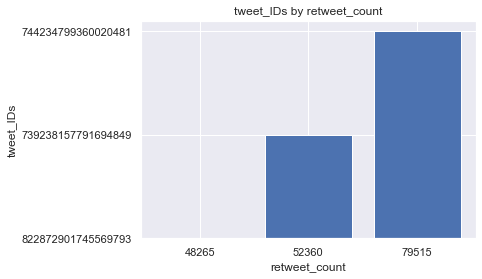

As mentioned in the wrangle_act.ipynb file,Tweet source provides information about the Tweet and its author.Hence why we needed to know where most tweets on the weratedogs twitter archive come from. It helps understand how a tweet was posted.Twitter for iphone is really a source where most authors posted from,liked and retweeted from. Safe to say our Users are majorly IPHONE users.

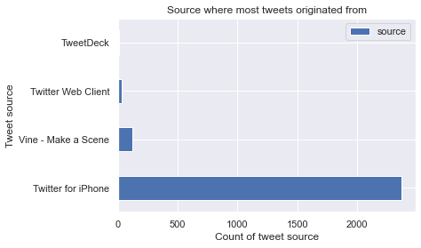

From the first 3 consecutive visualization, The Three charts displayed in quick succession shows that Labrador retriever is one of the most commonly occurring dog breed based on this Twitter data followed closely by Golden retriever. As seen also in the mean of 66% on the First prediction,down to 14% on the Second prediction for the Labrador retriever dog breed compared to the mean of 72% on the First prediction,down to 11% on the Second prediction for the Golden_retriever.So close!!!

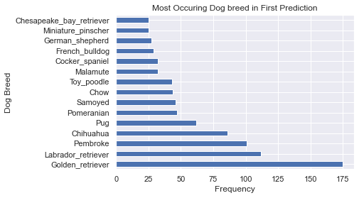

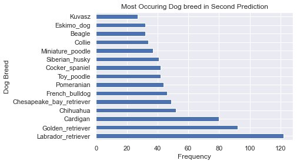

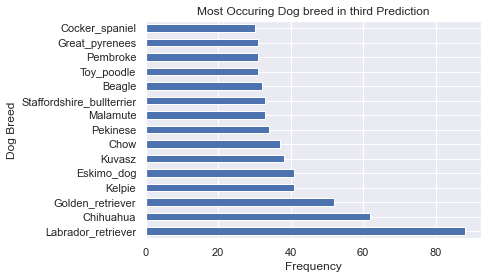

# Limitations

The missing values in most of the columns tried to hinder my analysis for the favorite count, tweet_IDs by retweet count viz. as i had to fill the empty and missing rows with "np.nan".

Also the outlier for rating numerator,the gap from 75percentile of rating numerator to the max, same for rating denominator; this might be due to not being sure if this was an error from user or what exact number to include.This might have some effect on the dataset and make our findings somewhat not accurate.

LIST OF WEBSITES - www.stackoverflow.com , www.google.com